## Course: VISUAL ANALYTICS FOR POLICY AND MANAGEMENT

### Prof. José Manuel Magallanes, PhD

- Visiting Professor of Computational Policy at Evans School of Public Policy and Governance, and eScience Institute Senior Data Science Fellow, University of Washington.
- Professor of Government and Political Methodology, Pontificia Universidad Católica del Perú.

# Tabular data: Univariate Numerical

1. Counting
2. Measuring

Let’s load the data we used for the last session:

```r
# clean memory
rm(list = ls())
# link
link='https://github.com/EvansDataScience/data/raw/master/eduwa.rda'

#getting the data TABLE from the file in the cloud:
load(file=url(link))
```

## Data from Counting

Counting expresses numerical values. They could be represented with bar plots if their frequency table had few discrete values, but that is not generally the case. For example, the variable *Reduced.Lunch* informs how many kids there are in each school that have that lunch for a reduced price. We have more than 2000 schools, so it is unlikely we find few different values. This is how many different values we have:

```r
# how many unique values
length(unique(eduwa$Reduced.Lunch))
```

```
## [1] 172
```

There are too many different values. Then, the bar plot is not a good idea (and neither a frequency table), as the bar plot produces a bar for *each* unique value in the data, counting how many times this value appears. This is how a bar plot looks for this variable:

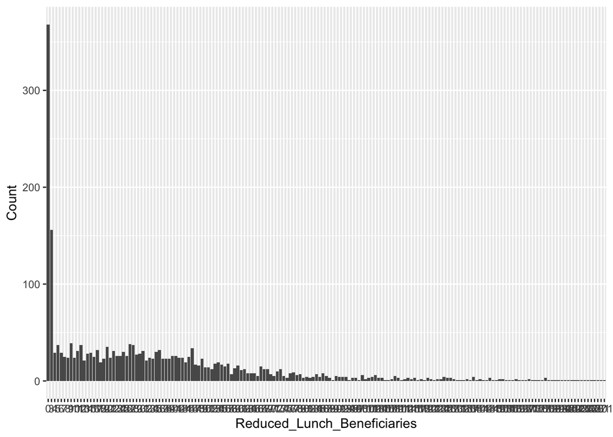

```r
lunchDF=as.data.frame(table(eduwa$Reduced.Lunch))
names(lunchDF)=c("Reduced_Lunch_Beneficiaries","Count")

library(ggplot2)
base1=ggplot(data=lunchDF, aes(x=Reduced_Lunch_Beneficiaries,Count))
bar1=base1+geom_bar(stat = "identity")
bar1
```

Numerical data requires statistical exploration with some questions in mind:

- What is the representative value? Generally the **mean**, or **median**.
- How good is the representative value? You need some measure of dispersion. For the mean you have the **standard deviation** and **coefficient of variation**, and for the median the **median absolute deviation**.
- Does the shape of the distribution differs from a *normal* distribution? If there is **asymmetry**, is it large enough to show **outliers**? You need some measure of symmetry and shape (a.k.a. *kurtosis*).

First, let’s take a look at the basic statistical information:

```r
summary(eduwa$Reduced.Lunch)
```

```
##    Min. 1st Qu.  Median    Mean 3rd Qu.    Max.    NA's
##    0.00    5.00   25.50   33.53   47.00  301.00     131
```

This information may give us a general idea on how the data on *reduced lunch* is behaving, so we select the plot that highlights that behavior. Let me try a box plot:

1. Keep all the *summary* values but the count of NAs.

```r
(statVals=summary(eduwa$Reduced.Lunch,digits = 3)[1:6])
```

```
##    Min. 1st Qu.  Median    Mean 3rd Qu.    Max.
##     0.0     5.0    25.5    33.5    47.0   301.0
```

Let me put some of those values in the boxplot y-axis:

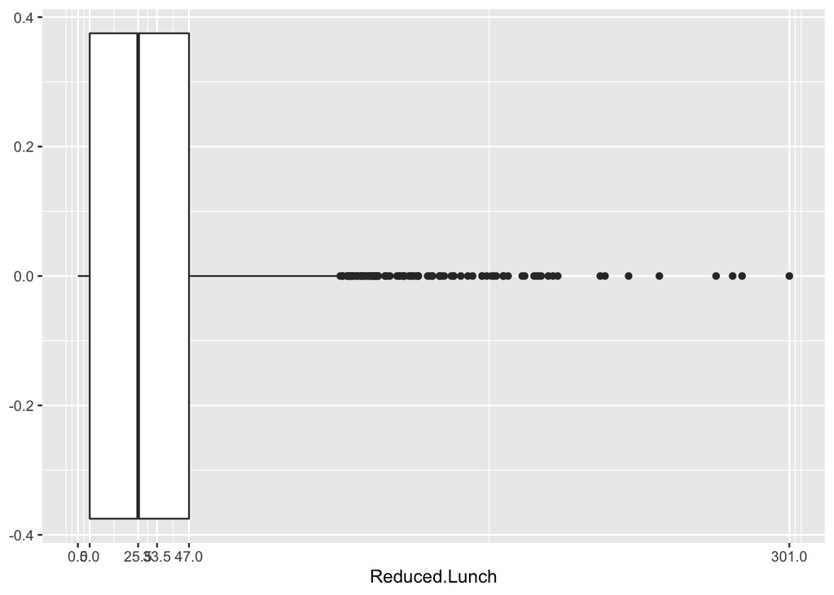

```r
library(magrittr)
# the summary values as vector
statVals=statVals%>%as.vector() #notice '%>%'

#plotting
base= ggplot(eduwa,aes(y = Reduced.Lunch))
b1= base + geom_boxplot()
b1=b1 +coord_flip()
b1=b1+ scale_y_continuous(breaks = statVals) #custom breaks
b1
```

This boxp lot shows outliers on the right tail, that means there is theoretical upper limit or threshold different than the maximum value of the variable. I can get that threshold this way:

1. Compute the interquartile range (difference between q3 and q1):

```r
(theIQR=IQR(eduwa$Reduced.Lunch,na.rm = T))
```

```
## [1] 42
```

Then, you multiply the IQR by a factor (typically 1.5). That value is added to the third quartile and the result is the upper threshold (if there were a lower threshold you would substract):

```r
# the upper threshold
(upperT=summary(eduwa$Reduced.Lunch)[[5]] + theIQR*1.5)
```

```
## [1] 110
```

Knowing the upper threshold, I can compute the amount of outliers in the right tail:

```r
(numOutliers=sum(eduwa$Reduced.Lunch>upperT,na.rm = T))
```

```
## [1] 96
```

I can annotate my boxplot with this value:

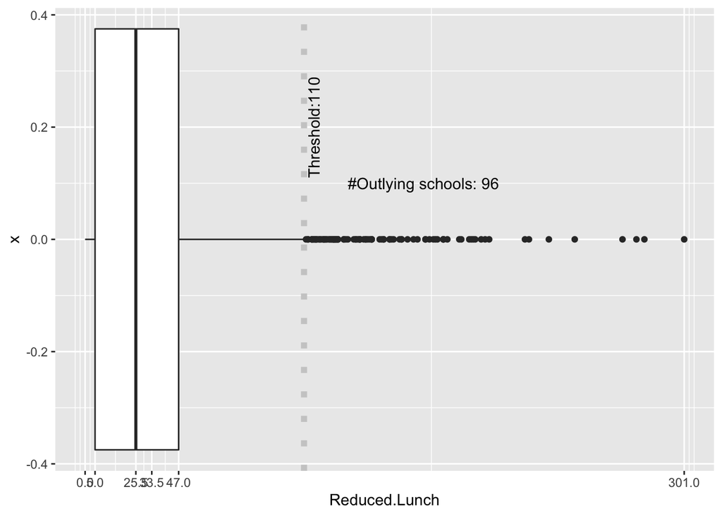

```r
txtUpper=paste0('Threshold:',upperT)
txtOut=paste0('#Outlying schools: ',numOutliers)

b1_line = b1 + geom_hline(yintercept = upperT,
                            color='grey80',
                            linetype="dotted",
                            size=2)
b1_upper_line=b1_line + annotate(geom = 'text',
                                label=txtUpper,
                                y = upperT+5,
                                x=0.2,
                                angle=90) # text angle

b1_upper_line_out=b1_upper_line + annotate(geom = 'text',
                                label=txtOut,
                                y = upperT+60,
                                x=0.1,
                                angle=0)
b1_upper_line_out
```

You can get rid of the vertical axis values:

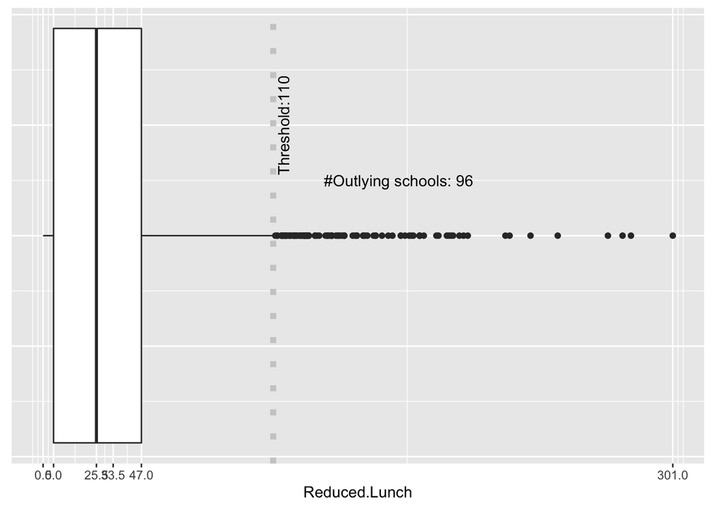

```r
b1_upper_line_out_noX=b1_upper_line_out +
                      theme(axis.text.y = element_blank(),
                            axis.ticks.y = element_blank(),
                            axis.title.y = element_blank())
b1_upper_line_out_noX
```

Also, chanege text location in the horizontal:

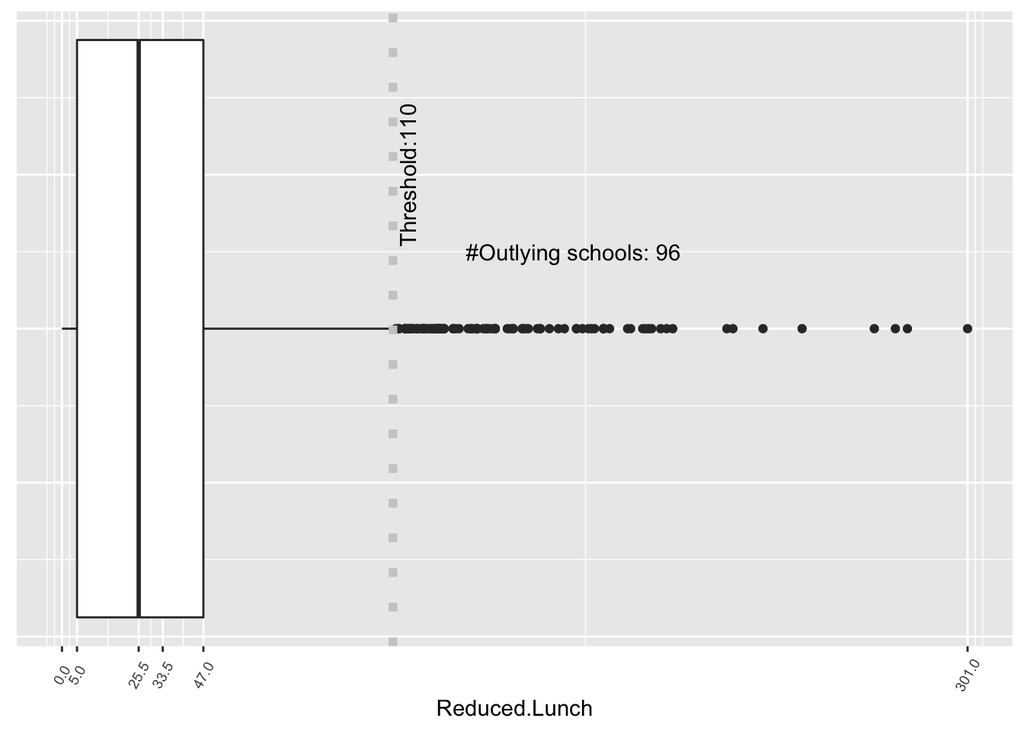

```r
b1_upper_line_out_noX + theme(axis.text.x = element_text(angle = 60,
                                                         size = 7,
                                                         vjust = 0.5))
```

In general, numerical data are prone to have outliers in real life (it is not common to speak about outliers in ordinal data since they have few levels).

The **summary** command can be supplemented with some measures of spread or dispersion:

```r
# standard deviation:
sd(eduwa$Reduced.Lunch,na.rm = T)
```

```
## [1] 36.55684
```

```r
# median absolute deviation:
mad(eduwa$Reduced.Lunch,na.rm = T)
```

```
## [1] 30.3933
```

```r
# coefficient of variation
library(DescTools)
CoefVar(eduwa$Reduced.Lunch,
        na.rm = T,
        unbiased=T,
        conf.level = 0.95)
```

```
##      est   low.ci   upr.ci
## 1.090575 1.035625 1.151947
```

There are also measures of shape:

```r
# asymmetry
Skew(eduwa$Reduced.Lunch,
     na.rm = T,
     conf.level = 0.95,
     ci.type = "bca",
     R=2500)
```

```
##     skew   lwr.ci   upr.ci
## 2.158124 1.900293 2.485147
```

```r
# kurtosis
Kurt(eduwa$Reduced.Lunch,
     na.rm = T,conf.level = 0.95,
     ci.type = "bca",R=2500)
```

```
##     kurt   lwr.ci   upr.ci
## 7.311024 5.057904 9.875646
```

And the confidence interval for the mean:

```r
# confidence interval for the mean
MeanCI(eduwa$Reduced.Lunch,
     na.rm = T)
```

```
##     mean   lwr.ci   upr.ci
## 33.53441 32.03831 35.03051
```

*What do we know right now?*

1. The data is skewed, with a right tail.
2. The data is concentrated in a small group of values.
3. In this situation, the median is more informative than the mean.

You can save those values for future annotations:

```r
cv=CoefVar(eduwa$Reduced.Lunch,na.rm = T)
sd=SD(eduwa$Reduced.Lunch,na.rm = T)
md=Median(eduwa$Reduced.Lunch,na.rm = T)
mn=Mean(eduwa$Reduced.Lunch,na.rm = T)
mn.low=MeanCI(eduwa$Reduced.Lunch,
     na.rm = T)[['lwr.ci']]
mn.up=MeanCI(eduwa$Reduced.Lunch,
     na.rm = T)[['upr.ci']]
sk=Skew(eduwa$Reduced.Lunch,
     na.rm = T)
```

A key visual for numerical data is the **histogram**. The histogram looks like a bar plot. In both cases the height of the bars represent counts, but the bars in the histogram are consecutive while the bases of the bars are numeric intervals (**binwidth** informs the length of the intervals). Histograms mainly help you see clearly where and how many *peaks* are there in the data distribution. Let’s make one:

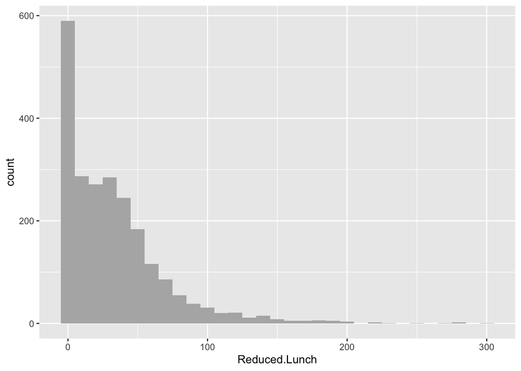

```r
#ggplot
WIDTH=10
library(ggplot2)
base= ggplot(eduwa)
h1= base + geom_histogram(aes(x = Reduced.Lunch),
                          binwidth = WIDTH,
                          fill='grey70')
h1
```

let’s do some annotations:

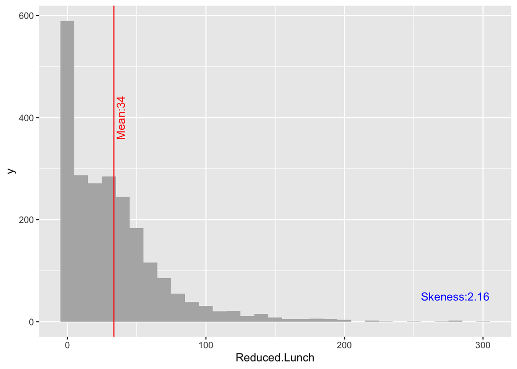

```r
# texts
annMean=paste0('Mean:',round(mn))
annSk=paste0('Skeness:',round(sk,2))

# adding
h1+ geom_vline(xintercept = mn,color='red') + # mean as line
    annotate(geom = 'text',color='red',
             label=annMean,
              y = 400,
              x=mn+5,
              angle=90) + # mean as value
    annotate(geom = 'text', color='blue',
             label=annSk,
              y = 50,
              x=upperT+170,
              angle=0) # skewness
```

What else would you do?

Go to table of contents.

### Measurement

A simplistic idea of measurement tells you the times a particular unit is present in the unit of analysis; which allows for the presence of decimal places. There are variables that could even have negative values.

Let’s analyze the variable *Student.Teacher.Ratio*:

```r
summary(eduwa$Student.Teacher.Ratio)
```

```
##    Min. 1st Qu.  Median    Mean 3rd Qu.    Max.    NA's
##    0.10   16.20   18.30   18.95   20.20  330.00     329
```

Notice that the maximum value is very far from the mean and the median, this announces the presence of outliers, which can be revealed with a boxplot:

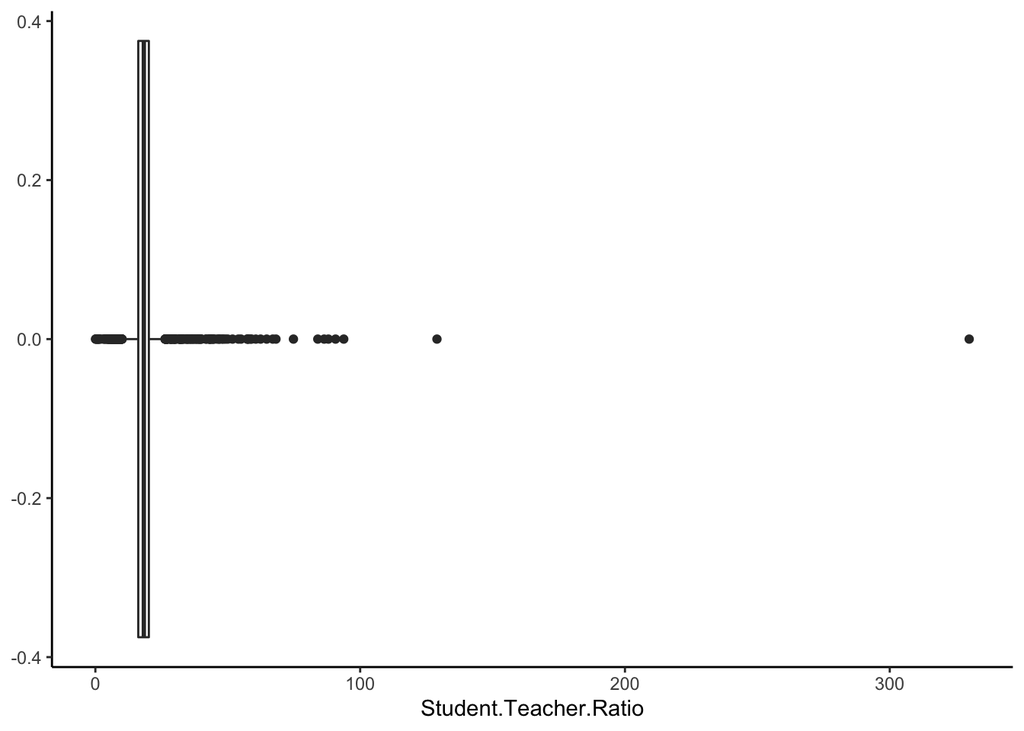

```r
base=ggplot(eduwa) + theme_classic()
box2=base + geom_boxplot(aes(y=Student.Teacher.Ratio))
box2=box2 + coord_flip()
box2
```

Now, let’s see if this is a multimodal distribution (more than one peak). Let’s take a look at the histogram:

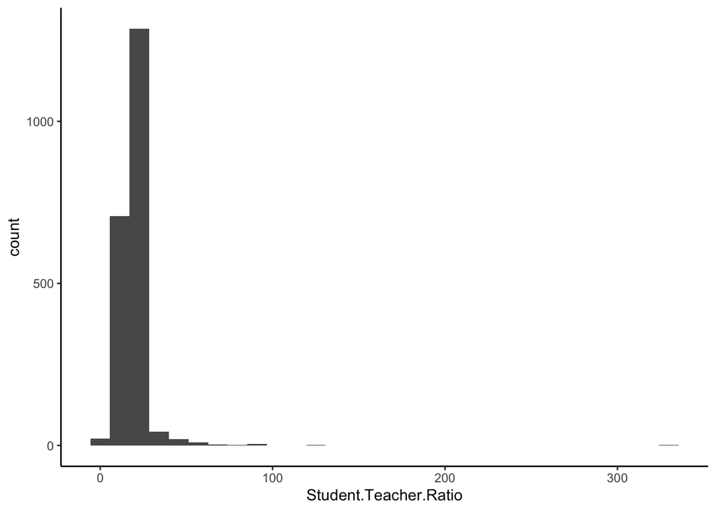

```r
hist2=base + geom_histogram(aes(x=Student.Teacher.Ratio))
hist2
```

You can recover the count of each bar in the histogram using **ggplot_built**:

```r
ggplot_build(hist2)$data[[1]]%>%head()
```

```
##      y count        x      xmin      xmax      density     ncount   ndensity
## 1   21    21  0.00000 -5.687931  5.687931 0.0008798923 0.01632970 0.01632970
## 2  708   708 11.37586  5.687931 17.063793 0.0296649388 0.55054432 0.55054432
## 3 1286  1286 22.75172 17.063793 28.439655 0.0538829255 1.00000000 1.00000000
## 4   42    42 34.12759 28.439655 39.815517 0.0017597845 0.03265941 0.03265941
## 5   20    20 45.50345 39.815517 51.191379 0.0008379926 0.01555210 0.01555210
## 6   10    10 56.87931 51.191379 62.567241 0.0004189963 0.00777605 0.00777605
##   flipped_aes PANEL group ymin ymax colour   fill size linetype alpha
## 1       FALSE     1    -1    0   21     NA grey35  0.5        1    NA
## 2       FALSE     1    -1    0  708     NA grey35  0.5        1    NA
## 3       FALSE     1    -1    0 1286     NA grey35  0.5        1    NA
## 4       FALSE     1    -1    0   42     NA grey35  0.5        1    NA
## 5       FALSE     1    -1    0   20     NA grey35  0.5        1    NA
## 6       FALSE     1    -1    0   10     NA grey35  0.5        1    NA
```

We can recover some of that information:

```r
(fromHist=ggplot_build(hist2)$data[[1]][,c('count','x','xmin','xmax')])
```

```
##    count         x       xmin       xmax
## 1     21   0.00000  -5.687931   5.687931
## 2    708  11.37586   5.687931  17.063793
## 3   1286  22.75172  17.063793  28.439655
## 4     42  34.12759  28.439655  39.815517
## 5     20  45.50345  39.815517  51.191379
## 6     10  56.87931  51.191379  62.567241
## 7      3  68.25517  62.567241  73.943103
## 8      2  79.63103  73.943103  85.318966
## 9      4  91.00690  85.318966  96.694828
## 10     0 102.38276  96.694828 108.070690
## 11     0 113.75862 108.070690 119.446552
## 12     1 125.13448 119.446552 130.822414
## 13     0 136.51034 130.822414 142.198276
## 14     0 147.88621 142.198276 153.574138
```

[output cut: 16 more lines]

Here, I want to know the modal class:

```r
(modeClassInfo=round(fromHist[which.max(fromHist$count),],2))
```

```
##   count     x  xmin  xmax
## 3  1286 22.75 17.06 28.44
```

Let me annotate:

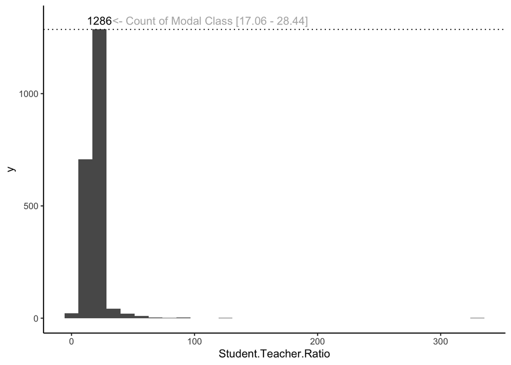

```r
# count for modal class
ModeCountY=modeClassInfo$count
# position of modal class
PositionCountX=modeClassInfo$x

ModeMessage=paste0("<- Count of Modal Class [",
                   modeClassInfo$xmin,' - ',
                   modeClassInfo$xmax,']')

hist2ann=hist2 + geom_hline(yintercept =ModeCountY,
                   linetype="dotted") +
    annotate(geom = 'text',
             label=ModeCountY,
              y = ModeCountY+40,
              x=PositionCountX,
              angle=0) +
    annotate(geom = 'text',
             label=ModeMessage,
              y = ModeCountY+40,
              x=PositionCountX+90,
             color='grey70',
              angle=0)
hist2ann
```

We know this variable has one peak, is highly skewed, and has outliers at the top and the bottom values. We could try to combine all that in one visual:

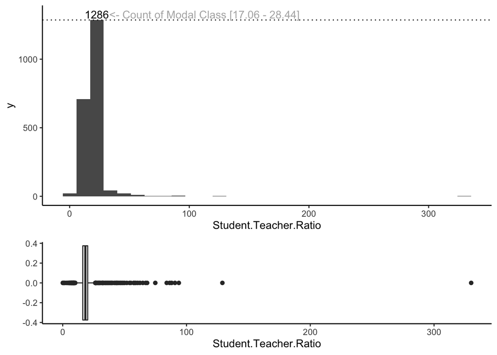

```r
library(ggpubr)
ggarrange(hist2ann,box2,align='v',ncol = 1,heights = 2:1)
```

As you see, that is not an exact match. An alternative can be the **violin** plot.

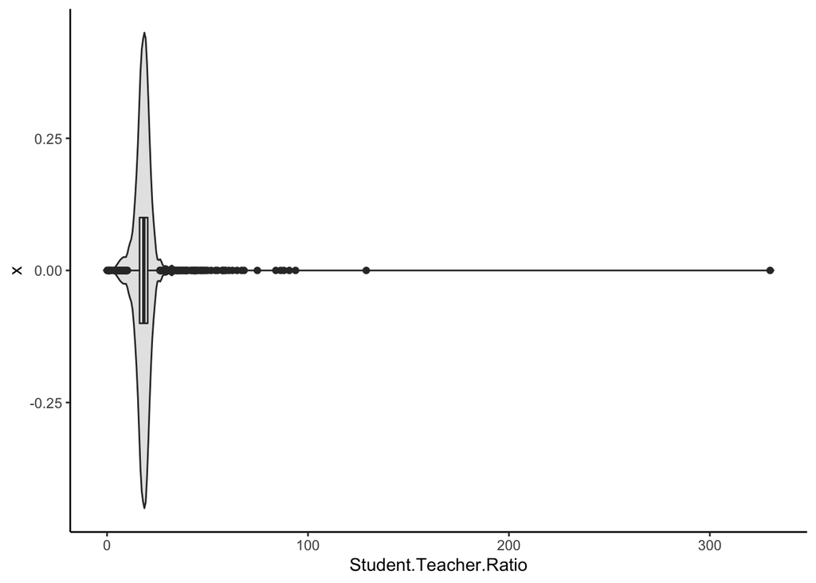

```r
base=ggplot(eduwa, aes(x=0,y=Student.Teacher.Ratio))+
            theme_classic()

vio=base+geom_violin(trim=FALSE, fill="gray90")

viobox=vio+geom_boxplot(width=0.2)
viobox=viobox + coord_flip()
viobox
```

We could inform the amount of outliers:

```r
theVar=eduwa$Student.Teacher.Ratio
theIQR=IQR(theVar,na.rm = T)
upperT=summary(theVar)[[5]] + theIQR*1.5
lowerT=summary(theVar)[[2]] - theIQR*1.5

# top
(numOutUp=sum(eduwa$Student.Teacher.Ratio>upperT,na.rm = T))
```

```
## [1] 102
```

```r
# bottom
(numOutLw=sum(eduwa$Student.Teacher.Ratio<lowerT,na.rm = T))
```

```
## [1] 83
```

We know there are 185 outliers (83 at the bottom values and 102 at the top). Let’s annotate the plot with that information:

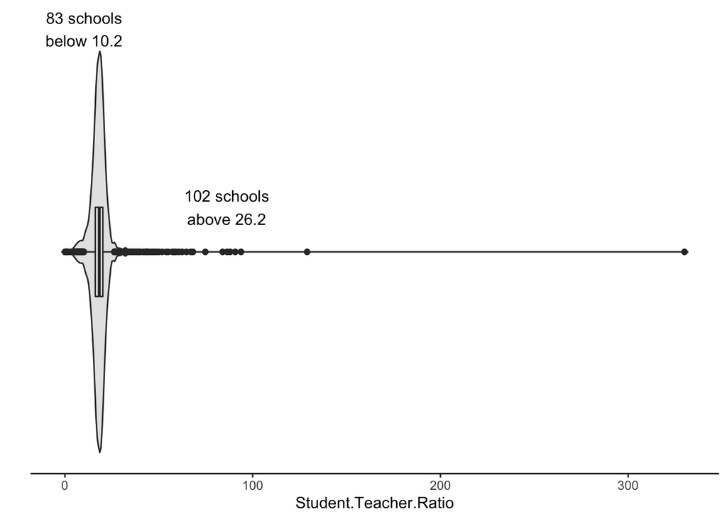

```r
# prepare texts:
annOutUN=paste0(numOutUp,' schools\nabove ',upperT)
annOutLN=paste0(numOutLw,' schools\nbelow ',lowerT)

# plotting
viobox=viobox  + labs(x='')
viobox + annotate(geom = 'text',
              label=annOutUN,
              y = upperT+60,
              x=0.1,
              angle=0) +
         annotate(geom = 'text',
              label=annOutLN,
              y = lowerT,
              x=0.5,
              angle=0) +
        theme(axis.text.y = element_blank(), # no text on y
              axis.ticks.y = element_blank(),# no ticks on y
              axis.line.y = element_blank()) # no line on y
```

The violin plot will inform the presence of peaks, but not on the maximum value of the peak as the histogram shows.

Go to table of contents.